# p8130_hw1_yl5508

Yifei LIU

2023/9/23

## Problem 1

**(a)** ordinal.  
**(b)** binary.  
**(c)** nominal.  
**(d)** continuous.  
**(e)** discrete.

## Problem 2

### Problem 2.1

```r
bikecrash_depscore = c(45, 39, 25, 47, 49, 5, 70, 99, 74, 37, 99, 35, 8, 59)
mean(bikecrash_depscore)
median(bikecrash_depscore)
range(bikecrash_depscore)
sd(bikecrash_depscore)
#Like var, sd uses denominator n−1.
```

[output not shown]

**(a)** Descriptive summaries: (mean) 49.36, (median) 46, (range) 5, 99, (sd) 28.85.

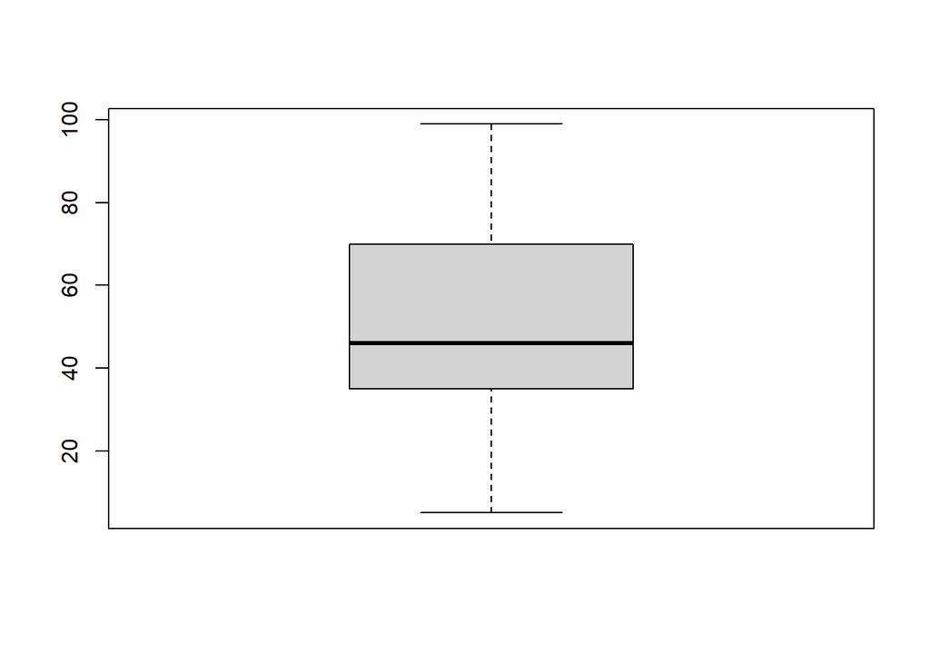

```r
boxplot(bikecrash_depscore)
```

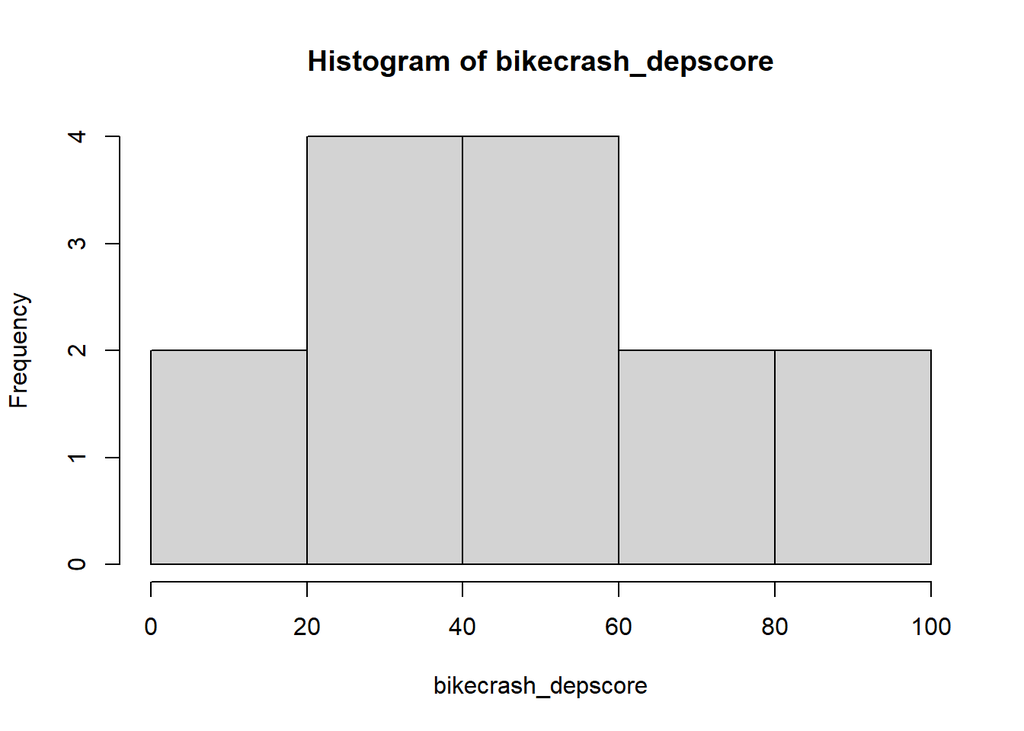

```r
hist(bikecrash_depscore)
```

### Problem 2.2

**(a)** side-by-side boxplot (bikecrash vs carcrash)

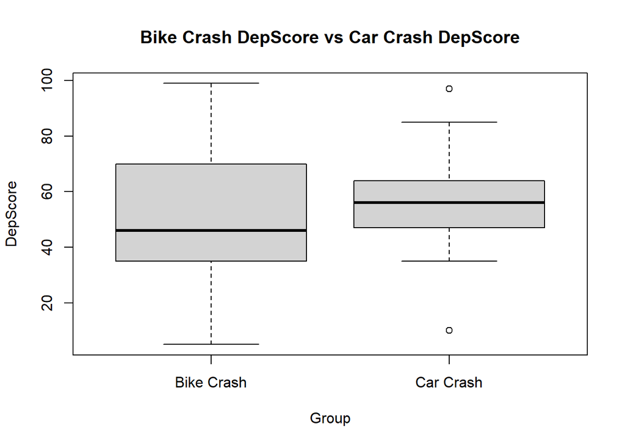

```r
carcrash_depscore = c(67, 50, 85, 43, 64, 35, 47, 97, 58, 58, 10, 56, 50)
boxplot(bikecrash_depscore, carcrash_depscore,
        xlab = "Group", ylab = "DepScore",
        names = c("Bike Crash", "Car Crash"),
        main = "Bike Crash DepScore vs Car Crash DepScore")
```

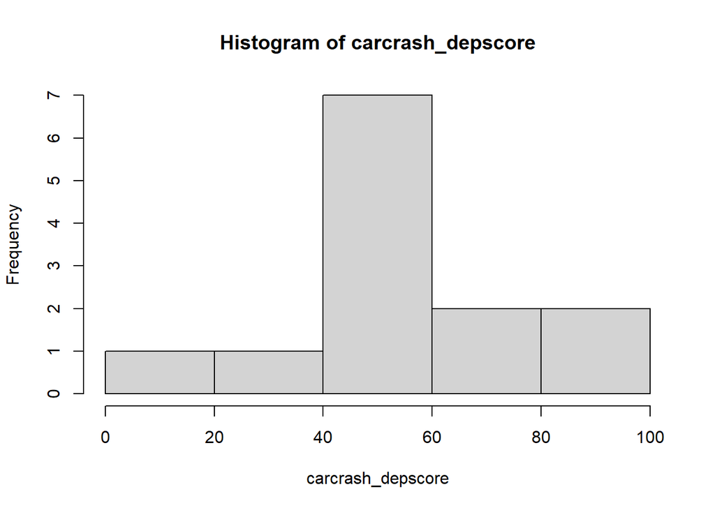

```r
hist(carcrash_depscore)
```

**(c)** Group Bike Crash probably have a lower typical depression score. Cause both the median(46) and mean(49.36) of the bike crash depression score are lower than those of car crash (median(56) and mean(55.38)).

## Problem 3

**(a)** $p(A) = 6/12 = 1/2$.  
**(b)** $p(B) = 1/12$.  
**(c)** $\because B \subset A\ \therefore p(B \cup A) = p(A) = 1/2$.  
**(d)** $\because p(A \cup B) = p(A) + p(B) - p(A \cap B)\ \therefore p(A \cap B) = p(A) + p(B) - p(A \cup B) = 1/2 + 1/12 -1/2 = 1/12$  
$\because p(A \cap B) \neq p(A) \times p(B)\ \therefore$ event A and B are not independent$.

## Problem 4

$event\ A:\ 75+\ y's\ woman\ has\ a\ positive\ scan\ finding$  
$event\ B:\ 75+\ y's\ woman\ has\ dementia$

$p(B) = 0.05$ $p(A|B) = p(A \cap B) / p(B) = 0.8$ $p(A|B^\complement) = p(A \cap B^\complement) / p(B^\complement) = 0.1$

$p(B^\complement) = 1 - p(B) = 0.95$ According to $Bayes'\ Rule$,  
$p(B|A) = \frac{p(A|B)\times p(B)}{p(A|B)\times p(B) + p(A|B^\complement)\times p(B^\complement)} = \frac{0.8\times 0.05}{0.8\times 0.05+0.1\times 0.95} \approx 0.296$  
So, the probability that the woman who has a positive scan finding may have dementia is 29.6%.